# Modelos de clasificación

- **Víctor Bucheli Guerrero**
- **Universidad del Valle**
- **Mayo 24 / 2018**

### Cargando los datos

El dataset consta de 88 tuplas y de 4 atributos: * Nombre: Nombre del carro * CaballosFuerza: indica los caballos de fuerza del carro * Precio: Precio del carro * Familiar: Variable que indica si el carro es familiar o no (1 familiar, 0 no familiar)

```r
#Cargamos el dataset
carros.dataset = read.csv("pricevshp.csv")
# Asignamos los nombres de las columnas
colnames(carros.dataset) <- c("Nombre","CaballosFuerza","Precio","Familiar")
carros.dataset
```

| Nombre | CaballosFuerza | Precio | Familiar |
| --- | --- | --- | --- |
| Merc 240D | 62 | 11900 | 1 |
| Ford Festiva 4 | 63 | 6319 | 1 |
| Toyota Corolla | 65 | 17872 | 1 |
| Fiat 128 | 66 | 3470 | 1 |
| Fiat X1-9 | 66 | 9640 | 1 |
| Subaru Justy 3 | 73 | 5866 | 1 |
| Pontiac LeMans 4 | 74 | 7254 | 1 |
| Toyota Tercel 4 | 78 | 6488 | 1 |
| Mercury Tracer 4 | 82 | 8672 | 1 |
| Ford Escort 4 | 90 | 7402 | 1 |

[output cut: 78 more lines]

### Graficando los datos

Cada vehículo representa un punto (xi, yi), en donde el eje *X* representa los caballos de fuerza que tiene el vehiculo y el eje *y* representa el precio. Pintamos la grafica diferenciando cada vehiculo por categoría (familiar, no familiar):

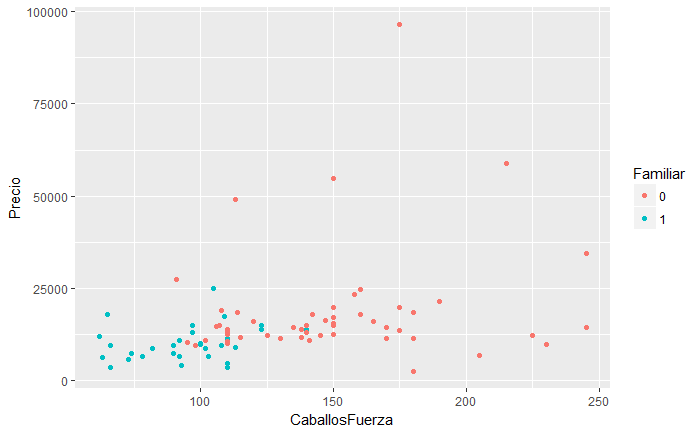

```r
require(ggplot2)
aux <- carros.dataset # Creamos una copia para cambiar el atributo Familiar a dato categórico y poder graficar
aux[, "Familiar"] <- as.factor(aux[, "Familiar"])
qplot(CaballosFuerza, Precio, data = aux, colour = Familiar)
```

### Diagrama de cajas y bigotes

Mediante el diagrama de cajas y bigotes observamos los valores atípicos que pueden traer malos resultados.

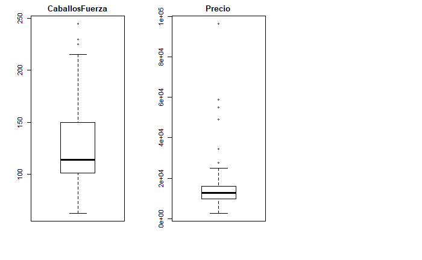

```r
par(mfrow=c(1, 3))#Obtenemos las tres gráficas  en el mismo cuadro de respuesta.
boxplot(carros.dataset[, "CaballosFuerza"], main="CaballosFuerza")  #Diagrama para "CaballosFuerza"
boxplot(carros.dataset[, "Precio"], main="Precio")  #Diagrama para el "Precio""
```

### Diagramas de densidad e histograma

El diagrama de densidad e histograma nos permite observar la distribución de las variables CaballosFuerza, Precio y Familiar

```r
#install.packages('e1071', dep = TRUE)
library(e1071)
par(mfrow=c(1, 3))#Obtenemos las dos gráficas  en el mismo cuadro de respuesta.
plot(density(carros.dataset[, "CaballosFuerza"]), main="Diagrama: Caballos de Fuerza", ylab="Frecuencia")
polygon(density(carros.dataset[, "CaballosFuerza"]), col="red")
```

```r
plot(density(carros.dataset[, "Precio"]), main="Diagrama: Precio", ylab="Frecuencia")
polygon(density(carros.dataset[, "Precio"]), col="red")
```

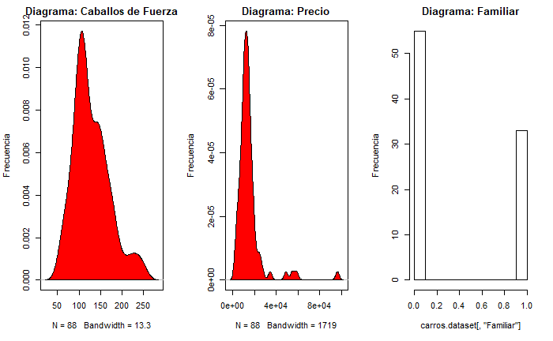

```r
hist(carros.dataset[, "Familiar"], main="Diagrama: Familiar" , ylab="Frecuencia") #Histograma
```

# Partir los datos en el conjunto de entrenamiento y de pruebas

Para el conjunto de entrenamiento se va a extraer el 70% de los datos de carros.dataset, el otro 30% se va a usar para el conjunto de pruebas, se inicializa en la misma semilla para hacer el experimento reproducible.

```r
set.seed(1234) # semilla
muestra.cantidad <- floor(0.7 * nrow(carros.dataset))
entrenamiento.index <- sample(seq_len(nrow(carros.dataset)), size = muestra.cantidad)
conjunto_entrenamiento <- carros.dataset[entrenamiento.index, ]
conjunto_prueba <- carros.dataset[- entrenamiento.index, ]
```

### Linear Discriminant Analysis

LDA busca combinaciones lineales de las variables independientes para explicar mejor los datos y predecir las diferentes clases. Los puntajes discriminantes se calculan para cada observación para cada clase basada en estas combinaciones lineales. R nos provee la función lda() la cual la usaremos para separar nuestros datos en 2 clases y verlo gráficamente.

Como podemos ver en la siguiente imagen, el LDA proyecta los puntos (vehiculos) en un hiperplano, ayudanbdo a diferenciar entre dos las clases.

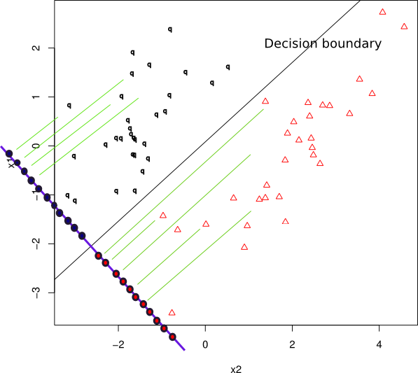

Al aplicar LDA con nuestro dataset, podemos ver las distribuciones de las clases encontradas:

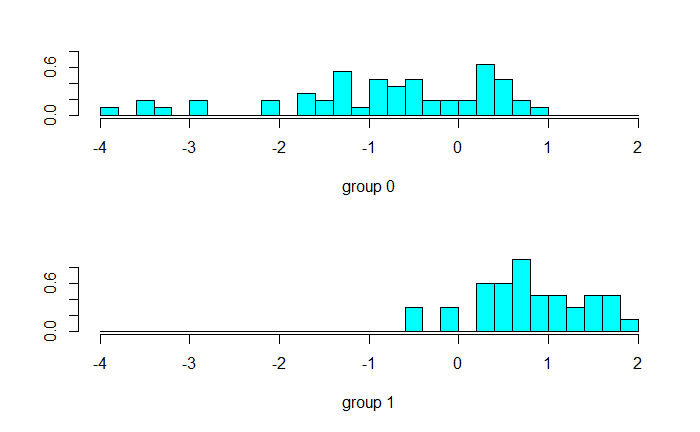

```r
require(ggplot2)
library(MASS)
# aplicamos lda() -> linear discriminant analysis
m1 <- lda(Familiar ~ CaballosFuerza + Precio, data = carros.dataset)
plot(m1)
```

Usando m1 que calculamos anteriormente, encontramos la pendiente y el intercepto de la recta que divide los datos (en familiares y no familiares), luego hacemos el diagrama de dispersión junto con esta recta.

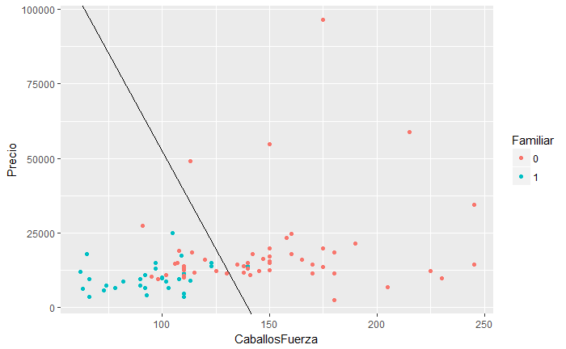

```r
gmean <- m1$prior%*%m1$means
const <- drop(gmean%*%m1$scaling)
pendiente <- -m1$scaling[1]/m1$scaling[2]
intercepto <- const/m1$scaling[2]
aux <- carros.dataset # Creamos una copia para cambiar el atributo Familiar a dato categórico y poder graficar
aux[, "Familiar"] <- as.factor(aux[, "Familiar"])
p <- qplot(CaballosFuerza, Precio, data = aux, colour = Familiar)  # Gráfico
p <- p + geom_abline(intercept = intercepto, slope = pendiente) # Línea
p #Pintamos
```

### Modelo lineal

Utilizando el conjunto de entrenamiento, entrenamos al modelo que va a intentar predecir la variable “Familiar”, utilizando los atributos “Precio” y “CaballosFuerza”

```r
modelo.lineal <- lm(Familiar ~ Precio + CaballosFuerza, data = conjunto_entrenamiento) # Modelo regresión lineal
summary(modelo.lineal)
```

```
Call:
lm(formula = Familiar ~ Precio + CaballosFuerza, data = conjunto_entrenamiento)

Residuals:
     Min       1Q   Median       3Q      Max
-0.61921 -0.29677 -0.05198  0.34900  0.70512

Coefficients:
                 Estimate Std. Error t value Pr(>|t|)
(Intercept)     1.312e+00  1.690e-01   7.760 1.55e-10 ***
Precio         -2.954e-06  3.957e-06  -0.747    0.458
CaballosFuerza -6.969e-03  1.267e-03  -5.500 8.96e-07 ***
---
Signif. codes:  0 ‘***’ 0.001 ‘**’ 0.01 ‘*’ 0.05 ‘.’ 0.1 ‘ ’ 1

Residual standard error: 0.3831 on 58 degrees of freedom
Multiple R-squared:  0.382, Adjusted R-squared:  0.3607
F-statistic: 17.92 on 2 and 58 DF,  p-value: 8.697e-07
```

# Gráfico del diagnostico (modelo lineal)

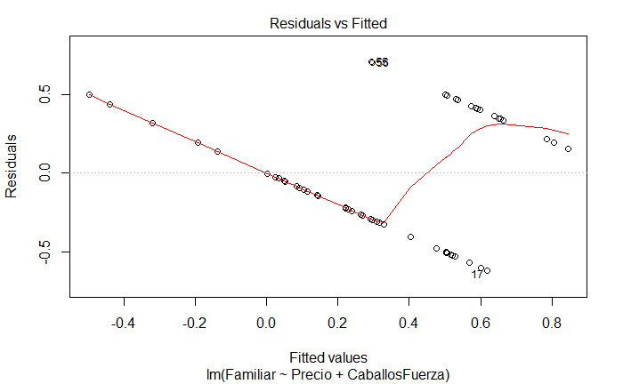

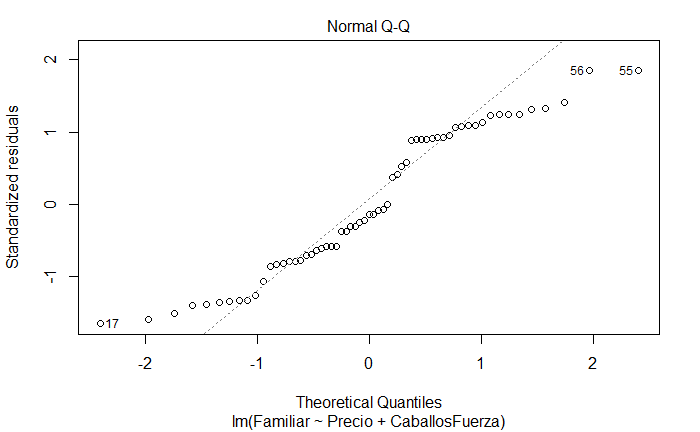

```r
plot(modelo.lineal, which=1:2)
```

## Predicción (usando modelo lineal)

Usamos el conjunto de pruebas y probamos el modelo. En la variable prediccion_lineal consta de 3 columnas, fit, lwr y upr. Utilizamos la columna fit que es el resultado de clasificar el conjunto de pruebas con el modelo.

```r
prediccion_lineal <-predict(modelo.lineal, conjunto_prueba, interval = "prediction")
prediccion_lineal
```

```
           fit         lwr       upr
2   0.85404635  0.06243991 1.6456528
4   0.84155437  0.05048052 1.6326282
5   0.82332779  0.03348441 1.6131712
7   0.77462124 -0.01169656 1.5609390
8   0.74900657 -0.03587993 1.5338931
9   0.71467742 -0.06821901 1.4975738
13  0.59633397 -0.19378233 1.3864503
23  0.57506553 -0.20203299 1.3521641
32  0.53490213 -0.24372654 1.3135308
35  0.51126961 -0.26379923 1.2863385
36  0.51394304 -0.26126960 1.2891557
37  0.50834805 -0.26663944 1.2833355
38  0.51562686 -0.25971034 1.2909641
39  0.50630679 -0.26867082 1.2812844
43  0.37949547 -0.44513662 1.2041276
44  0.49796822 -0.27729272 1.2732292
45  0.46277277 -0.31263403 1.2381796
47  0.42840080 -0.34540728 1.2022089
48  0.41030791 -0.36310401 1.1837198
49  0.41378485 -0.35960308 1.1871728
51  0.37179657 -0.40169667 1.1452898
63  0.20759209 -0.56708291 0.9822671
67  0.21539968 -0.55883855 0.9896379
71  0.12354165 -0.65457168 0.9016550
82 -0.07590327 -0.86162839 0.7098219
84 -0.36062541 -1.21031560 0.4890648
85 -0.29225795 -1.10224551 0.5177296
```

## Matriz de confusión para las predicciones (lineal)

Una matriz de confusión es una herramienta que permite la visualización del desempeño de un algoritmo que se emplea en aprendizaje supervisado. Cada columna de la matriz representa el número de predicciones de cada clase, mientras que cada fila representa a las instancias en la clase real.

Convertimos a categoría el atributo “Familiar” del conjunto de prueba para poder compararlo con las predicciones

```r
factor_prueba <- as.factor(conjunto_prueba[, "Familiar"])
```

Se deben redondear las predicciones resultantes a el entero más cercano para poder compararlas con la clase verdadera. Podemos observar que se obtuvo una precisión 70% con el conjunto de pruebas.

```r
library(caret)
pred_lineal <- as.vector(prediccion_lineal[, "fit"])
pred_lineal <- as.factor(ifelse(pred_lineal > 0.5, 1, 0)) # Cambiamos valores a 1s y 0s
# Creamos las matriz de confusión
confusionMatrix(factor_prueba, pred_lineal)
```

```
Confusion Matrix and Statistics

          Reference
Prediction  0  1
         0 10  5
         1  3  9

               Accuracy : 0.7037
                 95% CI : (0.4982, 0.8625)
    No Information Rate : 0.5185
    P-Value [Acc > NIR] : 0.04012

                  Kappa : 0.4098
 Mcnemar's Test P-Value : 0.72367

            Sensitivity : 0.7692
            Specificity : 0.6429
         Pos Pred Value : 0.6667
         Neg Pred Value : 0.7500
             Prevalence : 0.4815
         Detection Rate : 0.3704
   Detection Prevalence : 0.5556
      Balanced Accuracy : 0.7060

       'Positive' Class : 0
```